# Data Aggregation and Sanity Checking

Part of Nolan, et al 2018

Nick Waters

30/01/2018

# clean data

Here are the paths to the cleaned data:

```r
outpath = file.path("..", "data","processed", "aggregated_clean_summarized.csv")
clean_dir <- file.path("..", "data", "clean")
ch4_path <- file.path(clean_dir, "2018-03-03", "CH4.csv")
nh3_path <- file.path(clean_dir, "2018-03-02", "NH3.csv")
vs_path <- file.path(clean_dir, "2018-03-02", "VS.csv")
cod_path <- file.path(clean_dir, "2018-03-03", "COD.csv")
pH_path <- file.path(clean_dir, "2018-03-02", "pH.csv")
cfu_data_path <- file.path(clean_dir, "2018-03-09", "CFUs.csv")

ch4_data <- read.csv(ch4_path)
nh3_data <- read.csv(nh3_path)
vs_data  <- read.csv(vs_path)
cod_data <- read.csv(cod_path)
pH_data  <- read.csv(pH_path)
cfu_data <- read.csv(cfu_data_path)
```

For details of the data cleaning, see the `README` file in `data/clean/`

# Methane

Lets start with the methane data. At this point, the data has been cleaned and put in machine-readable format (see columns “clean_*" in `data/raw/UCD Spike 1 Frontiers Final 2018-03-02.xlsx/`)

```r
ch4_data$id <-ifelse(ch4_data$id == "", NA, as.character(ch4_data$id))

ch4_data <- ch4_data %>%
  fill(id, biogas_volumn_ml, stp_at_37_normalizing_factor)  # these are just reported once, but for later calculations we need them for each row

# p
ch4_data$biorep <- as.factor(ifelse(grepl("^R[1|2|3].*$", ch4_data$id),
                          (gsub("^R(.).*$", "\\1", ch4_data$id)), # biorectors
                          (gsub("^P[0|1|2|3|4|5]R(.).*$", "\\1", ch4_data$id))))  # batch
ch4_data$treatment <- as.factor(ifelse(grepl("^R[1|2|3].*$", ch4_data$id),
                          "10L", # biorectors
                          (gsub("^(P[0|1|2|3|4|5])R(.).*$", "\\1", ch4_data$id))))  # batch
# handle the partial readings that need to be summed; if only a single reading, we still need to group by it so we add a dummy "A"
ch4_data$partial <- ifelse(grepl("^(.*)[A|B|C]$", ch4_data$id),
                           gsub("^(.*)([A|B|C])$", "\\2", ch4_data$id),
                           "A")
ch4_data <- ch4_data %>%
  group_by(day, treatment, biorep, partial) %>%
  mutate(techrep = row_number())
```

here we combine the data from the partial readings (when gas bags were filled multiple times due to high output of biogas)

```r
ch4_data <- ch4_data %>%
  group_by(day, treatment, biorep, partial) %>%
  mutate(
    partial_ch4_percent= GC_value / ch4_standard_1_percent,
    partial_volume_pure_ch4=(partial_ch4_percent/100) * biogas_volumn_ml * stp_at_37_normalizing_factor)
```

Now, we account for the partial bags/syringes by summing at the technical replicate level

```r
ch4_data <- ch4_data %>%
  group_by(day, treatment, biorep, techrep) %>%
  mutate(total_biorep_volume_pure_ch4 = sum(partial_volume_pure_ch4),
         weighted_ch4_percent = weighted.mean(partial_ch4_percent, partial_volume_pure_ch4))
```

Looking at the data, our values look similar to those previously calculated, but we have retained the technical level values for replication. Lets get rid of the data we no longer need.

```r
summarize_process_data <- function(df, value_col, measure, sanity_col, sanity_threshold){
  # takes a dataframe and selects the columns of interest, deleting the rest
  # if given a sanity column, that will be checked to see if the values are the same within some threshold empirically set
  sdf <- df %>%
    select_("day", "treatment", "biorep", "techrep", value_col, sanity_col) %>%
    as.data.frame()
  sdf <- sdf %>%
    fill(sanity_col)# often these need to be filled down, as only one value is present
  # drop any NA's life is short, and this will be apparent later in the analysis
  sdf <- sdf[rowSums(is.na(sdf)) == 0,]

  sdf$diff <- abs(sdf[, value_col] - sdf[, sanity_col])
  sdf$thresh <- sanity_threshold
  if (any(sdf$diff > sdf$thresh)){
    warning("Some values appear pretty different between the precalcualted and current values!  Please check manually before proceeding" )
    weirdos  <- sdf[sdf$diff > sdf$thresh,]
  } else {
    weirdos <- data.frame()
  }
  sdf$diff <- NULL # do this before removing duplicates
  sdf$thresh <- NULL
  sdf[, sanity_col] <- NULL # do this before removing duplicates
  sdf <- sdf[!duplicated(sdf),]
  sdf$measure <- measure
  sdf$value <- sdf[, value_col]
  sdf[, value_col] <- NULL
  return(list(summary=sdf, wierdos=weirdos))
}


ch4_summary <- summarize_process_data(
  df =ch4_data,
  value_col = "weighted_ch4_percent",
  measure="CH4",
  sanity_col="combined_methane_percent", sanity_threshold=1.5 )
#print(ch4_summary$wierdos)
```

We have a calculated things slightly differently than previously. The old method was to average the technical replicates per partial reading per biological replicate, calculate the volume/percent/ etc for the partial readings , average across biological replicates. Here, we calculate the percentage/volume for each technical replicate (ie techrep 1 for partialA, partialB,partialC), and generate a technical replicate weighted. I think this is more accurate as it both combines the partial readings at a stage where we do not lose the technical replication.

And here’s a rough plot for sanity checking. Does this seem to agree with previous plots? (Note here we are averaging the tech reps)

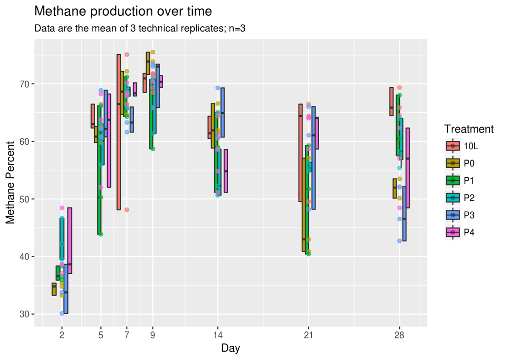

```r
ggplot(ch4_summary$summary %>% group_by(day, treatment, biorep) %>%
         mutate(biorep_mean_agg_ch4=mean(value)),
       aes(x=day, y=biorep_mean_agg_ch4,
           group=interaction(treatment, day),
           fill=treatment)) +
  scale_x_continuous(breaks=unique(ch4_summary$summary$day) ) +
  geom_boxplot() +
  geom_jitter(width=.01, height=.01, aes(color=treatment), alpha=.3) +
  scale_color_discrete(guide=FALSE)+
  labs(
    title="Methane production over time",
    subtitle="Data are the mean of 3 technical replicates; n=3",
    x="Day",
    y="Methane Percent",
    fill="Treatment"
  )
```

# Ammonia

```r
nh3_data$biorep <- as.factor(ifelse(grepl("^R[1|2|3].*$", nh3_data$id),
                          (gsub("^R(.).*$", "\\1", nh3_data$id)), # biorectors
                          (gsub("^P[0|1|2|3|4|5]R(.).*$", "\\1", nh3_data$id))))  # batch
nh3_data$treatment <- as.factor(ifelse(grepl("^R[1|2|3].*$", nh3_data$id),
                          "10L", # biorectors
                          (gsub("^(P[0|1|2|3|4|5])R(.).*$", "\\1", nh3_data$id))))  # batch
nh3_data <- nh3_data %>%
  group_by(day, treatment, biorep) %>%
  mutate(techrep = row_number(),
         mg_NH3_per_L_confirm = 50 * dilue_value_1_in_50,
         tech_mean_nh3 = mean(mg_NH3_per_L_confirm))

# sanity check that the values calcualted here roughly match existing values
nh3_data <- nh3_data %>%
  group_by(day, treatment) %>%
  mutate(mean_nh3 = mean(tech_mean_nh3 ))
# subset out relevent data
nh3_summary <- summarize_process_data(
  df = nh3_data,
  value_col = "tech_mean_nh3",
  measure="NH3",
  sanity_col="average_mg_nh3_per_L", sanity_threshold=100 )
```

```
## Warning in summarize_process_data(df = nh3_data, value_col =
## "tech_mean_nh3", : Some values appear pretty different between the
## precalcualted and current values! Please check manually before proceeding
```

```r
nh3_summary$wierdos
```

```
##     day treatment biorep techrep tech_mean_nh3 average_mg_nh3_per_L
## 83   21        P4      2       1          1125             978.3333
## 84   21        P4      3       1           740             978.3333
## 93   28        P0      3       1           910            1041.6667
## 99   28        P2      3       1           825             961.6667
## 103  28        P4      1       1          1090             940.0000
## 105  28        P4      3       1           810             940.0000
##         diff thresh
## 83  146.6667    100
## 84  238.3333    100
## 93  131.6667    100
## 99  136.6667    100
## 103 150.0000    100
## 105 130.0000    100
```

I get a few warnings, but due to the lack of technical replication, this isn’t surprising. manual inspection shows things to look OK.

And lets take a quick look

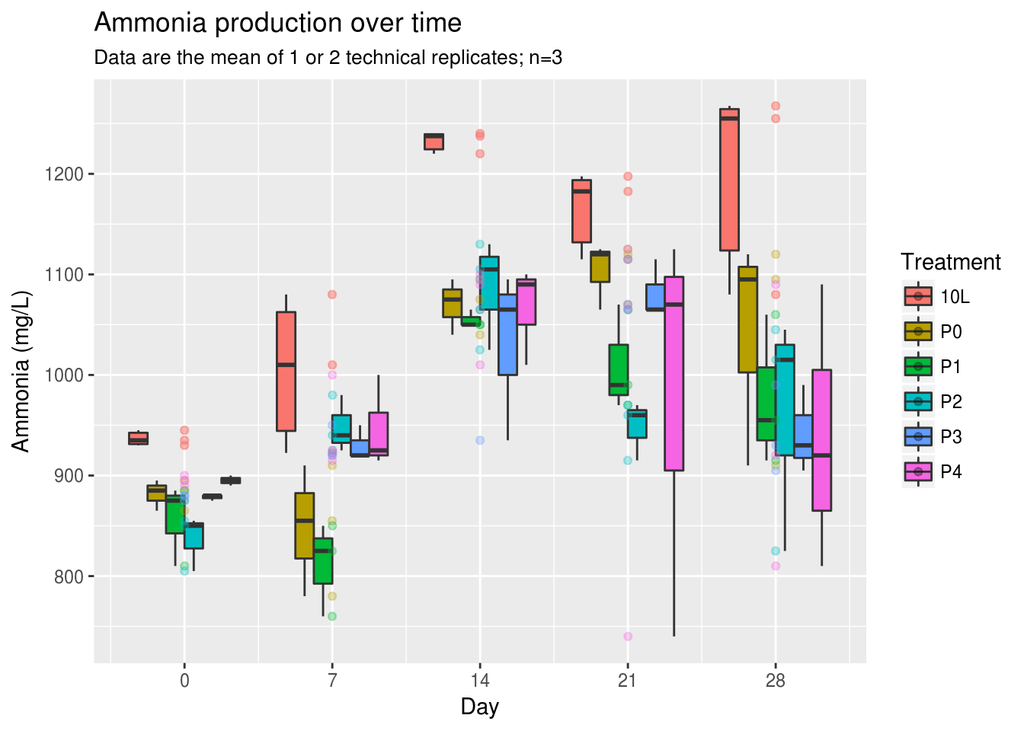

```r
ggplot(nh3_summary$summary %>% group_by(day, treatment, biorep) %>%
         mutate(mean_val=mean(value)),
       aes(x=day, y=mean_val,
           group=interaction(treatment, day),
           fill=treatment)) +
  scale_x_continuous(breaks=unique(nh3_summary$summary$day) ) +
  geom_boxplot() +
  geom_jitter(width=.01, height=.01, aes(color=treatment), alpha=.3) +
  scale_color_discrete(guide=FALSE)+
  labs(
    title="Ammonia production over time",
    subtitle="Data are the mean of 1 or 2 technical replicates; n=3",
    x="Day",
    y="Ammonia (mg/L)",
    fill="Treatment"
  )
```

# Volitile Solids

It is important to note that the Feed-stock is treated as a single unit, and all the replicates are technical. These values do not get used much, but serve as a reference. Overall, The interesting comparison in these reactors is how the digestate (reactor contents at the end of 28 days) compares to the feedstock in terms of pathogen dieoff, COD removal, etc.

```r
# handle the Feed Stock column : we make it look like a reactor.

#This gets it treated as technical replication.
vs_data$id <- gsub("FS(\\d)", "F1", vs_data$id)

#This gets it treated as biological replication.
# vs_data$id <- gsub("FS(\\d)", "F\\1A", vs_data$id)

vs_data$biorep <- as.factor(ifelse(grepl("^[R|F]\\d.*$", vs_data$id),
                          (gsub("^[R|F](.).*$", "\\1", vs_data$id)), # biorectors
                          (gsub("^P[0|1|2|3|4|5]R(.).*$", "\\1", vs_data$id))))  # batch
# as technical
vs_data$treatment <- as.factor(ifelse(grepl("^R[1|2|3].*$", vs_data$id),
                          "10L", # biorectors
                          (gsub("^(P[0|1|2|3|4|5])R(.).*$", "\\1", vs_data$id))))  # batch
# as biological
# vs_data$treatment <- as.factor(ifelse(grepl("^[R|F].*\\d.*$", vs_data$id),
#                           ifelse(grepl("^R[1|2|3].*$", vs_data$id), "10L", "FS"), # biorectors
#                           (gsub("^(P[0|1|2|3|4|5])R(.).*$", "\\1", vs_data$id))))  # batch

vs_data <- vs_data %>%
  group_by(day, treatment, biorep) %>%
  mutate(techrep = row_number(),
         vs_percent_2 = (dry_weights -ash_weight) / (wet_combined_weight - glass_weight) * 100,
         tech_mean_vs = mean(vs_percent_2))

vs_summary <- summarize_process_data(
  df = vs_data,
  value_col = "vs_percent_2",
  measure="VS",
  sanity_col="vs_percent", sanity_threshold=.1 )
```

And lets take a quick look

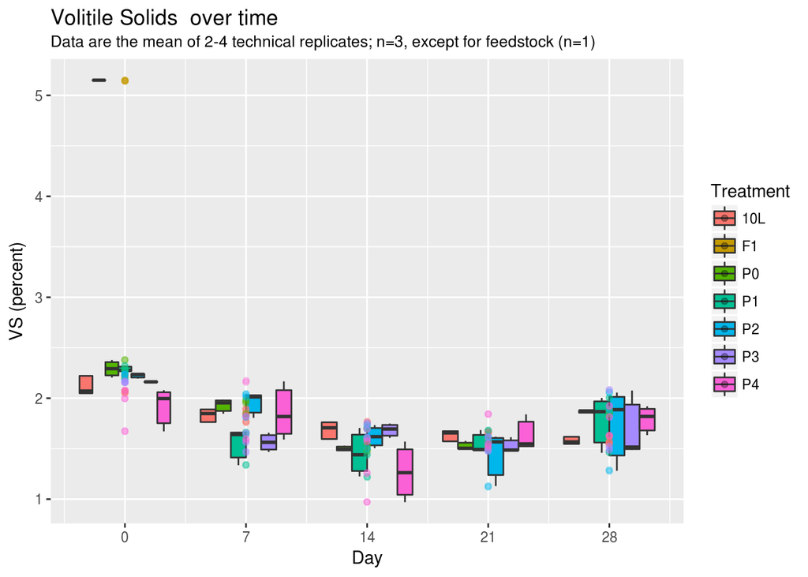

```r
ggplot(vs_summary$summary %>% group_by(day, treatment, biorep) %>%
         mutate(mean_val=mean(value)),
       aes(x=day, y=mean_val,
           group=interaction(treatment, day),
           fill=treatment)) +
  scale_x_continuous(breaks=unique(vs_summary$summary$day) ) +
  geom_boxplot() +
  geom_jitter(width=.01, height=.01, aes(color=treatment), alpha=.3) +
  scale_color_discrete(guide=FALSE)+
  labs(
    title="Volitile Solids  over time",
    subtitle="Data are the mean of 2-4 technical replicates; n=3, except for feedstock (n=1)",
    x="Day",
    y="VS (percent)",
    fill="Treatment"
  )
```

# Chemical Oxygen Demand

Here’s a question: It looks like COD is calculated by
$$(blankmean - GCreading) * molarityOfStandard * 4000$$
>Where does the 4000 come from?

```r
#This gets it treated as technical replication.
cod_data$id <- gsub("FS(\\d)", "F1", cod_data$id)

#This gets it treated as biological replication.
# cod_data$id <- gsub("FS(\\d)", "F\\1A", cod_data$id)

cod_data$biorep <- as.factor(ifelse(grepl("^[R|F]\\d.*$", cod_data$id),
                          (gsub("^[R|F](.).*$", "\\1", cod_data$id)), # biorectors
                          (gsub("^P[0|1|2|3|4|5]R(.).*$", "\\1", cod_data$id))))  # batch
# as technical
cod_data$treatment <- as.factor(ifelse(grepl("^R[1|2|3].*$", cod_data$id),
                          "10L", # biorectors
                          (gsub("^(P[0|1|2|3|4|5])R(.).*$", "\\1", cod_data$id))))  # batch
# as biological
# cod_data$treatment <- as.factor(ifelse(grepl("^[R|F].*\\d.*$", cod_data$id),
#                           ifelse(grepl("^R[1|2|3].*$", cod_data$id), "10L", "FS"), # biorectors
#                           (gsub("^(P[0|1|2|3|4|5])R(.).*$", "\\1", cod_data$id))))  # batch


cod_data <- cod_data %>%
  group_by(day, measure, treatment, biorep) %>% # we make sure we group by  measurement as well!
  mutate(techrep = row_number())

cod_data$COD <-  (cod_data$standard_value - cod_data$GC_val) * cod_data$standard_molarity * 4000 * cod_data$dilution

sCOD_summary <- summarize_process_data(
  df = cod_data[cod_data$measure == "sCOD", ],
  value_col = "COD",
  measure="sCOD",
  sanity_col="COD_mg_per_l", sanity_threshold=.01 )
tCOD_summary <- summarize_process_data(
  df = cod_data[cod_data$measure == "tCOD", ],
  value_col = "COD",
  measure="tCOD",
  sanity_col="COD_mg_per_l", sanity_threshold=.01 )
cod_summary <- rbind(sCOD_summary$summary, tCOD_summary$summary)
```

And lets take a quick look

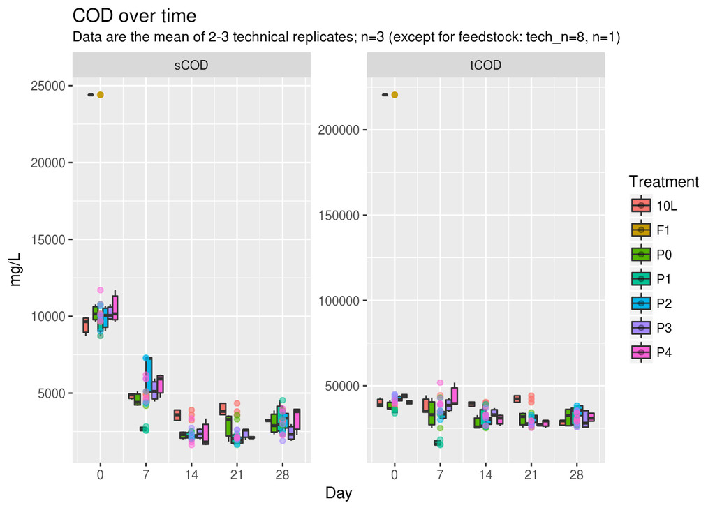

```r
ggplot(cod_summary %>% group_by(day, measure, treatment, biorep) %>%
         mutate(mean_val=mean(value)),
       aes(x=day, y=mean_val,
           group=interaction(treatment, day),
           fill=treatment)) +
  scale_x_continuous(breaks=unique(cod_summary$day) ) +
  facet_wrap(~measure, nrow=1, scale="free") +
  geom_boxplot() +
  geom_jitter(width=.01, height=.01, aes(color=treatment), alpha=.3) +
  scale_color_discrete(guide=FALSE)+
  labs(
    title="COD over time",
    subtitle="Data are the mean of 2-3 technical replicates; n=3 (except for feedstock: tech_n=8, n=1)",
    x="Day",
    y="mg/L",
    fill="Treatment"
  )
```

# pH

```r
pH_data$id <- gsub("FS(\\d)", "F1", pH_data$id)

pH_data$biorep <- as.factor(ifelse(grepl("^[R|F]\\d.*$", pH_data$id),
                          (gsub("^[R|F](.).*$", "\\1", pH_data$id)), # biorectors
                          (gsub("^P[0|1|2|3|4|5]R(.).*$", "\\1", pH_data$id))))  # batch
pH_data$treatment <- as.factor(ifelse(grepl("^R\\d.*$", pH_data$id),
                          "10L", # biorectors
                          (gsub("^(P\\d)R(.).*$", "\\1", pH_data$id))))  # batch
pH_data <- pH_data %>%
  group_by(day, treatment, biorep) %>%
  mutate(techrep = row_number(), pH2 = pH+0)

pH_summary <- summarize_process_data(
  df = pH_data,
  value_col = "pH",
  measure="pH",
  sanity_col="pH2", sanity_threshold=.0 )
```

We have no sanity checking here for the calculations, because there are no calculations!

And lets take a quick look

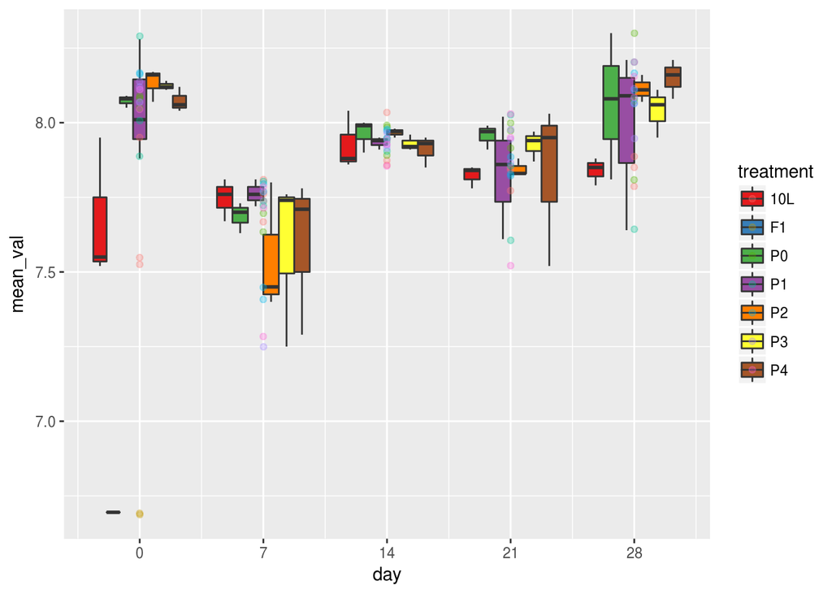

```r
ggplot(pH_summary$summary %>% group_by(day, treatment, biorep) %>%
         mutate(mean_val=mean(value)),
       aes(x=day, y=mean_val,
           group=interaction(treatment, day),
           fill=treatment)) +
  scale_x_continuous(breaks=unique(pH_summary$summary$day) ) +
  geom_boxplot() +
  geom_jitter(width=.01, height=.01, aes(color=treatment), alpha=.3) +
  scale_fill_brewer(palette = "Set1")
```

```r
  labs(
    title="pH  over time",
    subtitle="Data are the mean of 1-2 technical replicates; n=3 (feedstock n=1)",
    x="Day",
    y="pH",
    fill="Treatment"
  )
```

```
## $title
## [1] "pH  over time"
##
## $subtitle
## [1] "Data are the mean of 1-2 technical replicates; n=3 (feedstock n=1)"
##
## $x
## [1] "Day"
##
## $y
## [1] "pH"
##
## $fill
## [1] "Treatment"
##
## attr(,"class")
## [1] "labels"
```

# CFUs

The CFU data is the strangest of the measurements. Quantification was performed with the Colisure kits, which gives a values for Colony Forming Units for a given dilution.

```r
cfu_data$id <- gsub("FS(\\d)", "F1", cfu_data$id)
cfu_data$id[cfu_data$id == ""] <- NA
cfu_data$bug[cfu_data$bug == ""] <- NA
cfu_data <- cfu_data %>%
  fill(bug, id)  # these are just reported once, but for later calculations we need them for each row

cfu_data$biorep <- as.factor(ifelse(grepl("^[R|F]\\d.*$", cfu_data$id),
                          (gsub("^[R|F](.).*$", "\\1", cfu_data$id)), # biorectors
                          (gsub("^P[0|1|2|3|4|5]R(.).*$", "\\1", cfu_data$id))))  # batch
cfu_data$treatment <- as.factor(ifelse(grepl("^[R|F].*\\d.*$", cfu_data$id),
                          "10L", # biorectors
                          (gsub("^(P[0|1|2|3|4|5])R(.).*$", "\\1", cfu_data$id))))  # batch

cfu_data <- melt(
  cfu_data,
  id.vars = c("bug", "id", "day", "biorep", "Average", "treatment"),
  measure.vars = colnames(cfu_data)[grepl("x\\d*",colnames(cfu_data ))],
  variable.name = "multiplier")


cfu_data$multiplier <- as.numeric(gsub("x", "", cfu_data$multiplier))
cfu_data$day <- as.numeric(gsub("Day", "", cfu_data$day))

# watch the tech rep calculation; we have lots of NAs, so we only count those with readings
cfu_data <- cfu_data %>%
  group_by(bug, day, treatment, biorep) %>%
  filter(!is.na(value)) %>%
  mutate(techrep=row_number(), scaled_value = value * multiplier) %>%
  mutate(biomean = mean(scaled_value, na.rm=T))

cfu_summary <- summarize_process_data(
  df = cfu_data,
  value_col = "biomean",
  measure="CFUs",
  sanity_col="Average", sanity_threshold=10 )
```

```
## Warning in summarize_process_data(df = cfu_data, value_col = "biomean", :
## Some values appear pretty different between the precalcualted and current
## values! Please check manually before proceeding
```

```r
print(cfu_summary$wierdos)
```

```
##         bug day treatment biorep techrep biomean Average   diff thresh
## 243 E. coli   0        P1      1       1   86500  173000  86500     10
## 246 E. coli   0        P2      1       1   60000  120000  60000     10
## 247 E. coli   0        P2      2       1  120500  241000 120500     10
## 248 E. coli   0        P2      3       1   55000  110000  55000     10
## 293 E. coli   0        P1      1       2   86500  173000  86500     10
## 294 E. coli   0        P2      1       2   60000  120000  60000     10
## 295 E. coli   0        P2      2       2  120500  241000 120500     10
## 296 E. coli   0        P2      3       2   55000  110000  55000     10
```

We also need to fix some of the day 0 calculations for E. coli

We have three bug’s measurements in here, so we need to say that rather than “CFUs”, and get rid of the extra column:

```r
cfu_summary$summary$measure <- cfu_summary$summary$bug
cfu_summary$summary$bug <- NULL
```

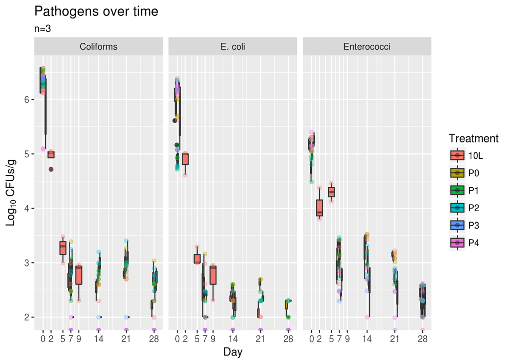

```r
ggplot(cfu_summary$summary %>% group_by(day, treatment, biorep, measure) %>%
         mutate(mean_val=mean(value)),
       aes(x=day, y=mean_val,
           group=interaction(treatment, day),
           fill=treatment)) +
  scale_x_continuous(breaks=unique(cfu_summary$summary$day) ) +
  facet_grid(~measure) +
  geom_boxplot() +
  scale_y_log10(breaks=c(1,10, 100, 1000, 10000, 100000, 1000000),
                labels=c("0", "1", "2", "3", "4", "5", "6")) +
  geom_jitter(width=.01, height=.01, aes(color=treatment), alpha=.3) +
  scale_color_discrete(guide=FALSE)+
  labs(
    title="Pathogens over time",
    subtitle="n=3",
    x="Day",
    y=expression(paste(Log[10], " CFUs/g")),
    fill="Treatment"
  )
```

# writing out checked data

Now we have all the important values summarized at the technical replicate level. Lets combined this and write out to a single file. To track when the data was generated without keeping around old aggregated data, we add a comment line before the header to give the date the file was generated.

```r
all_summary <- rbind(ch4_summary$summary, nh3_summary$summary, vs_summary$summary, sCOD_summary$summary, tCOD_summary$summary, pH_summary$summary, cfu_summary$summary)


outpath = file.path("..", "data","processed", "aggregated_clean_summarized.csv")
con <- file(outpath, open="wt")
writeLines(paste("# this data was aggregated by Nolan_et_al_2018/scripts/aggregate_data.Rmd on", Sys.Date()), con)
write.table(all_summary,
            file = con,
            sep = ",")
close(con)
```